# Prediction of Diabetes

20BCE1025 20BCE1430 20BCE1538 20BCE1458

Nov 4 2022

## Introduction

The diabetes is threatening a lot of people nowadays, without having a perfect cure for it.There are actually two types of diabetes,namely Type 1 and Type 2.The type 2 diabetes is commonly called as diabetes mellitus.It can be defined as a chronic condition that affects the way the body processes blood sugar (glucose).We consider the mellitus here.After deep researches we found that, that some parameters are directly responsible to for the mellitus to occur.By using the data of the people with and without diabetes,a dataset has been build.We use that dataset to classify the people who are in the risk of getting diabetes.

## Loading the required libraries

```r
library(ggplot2)
library(ggvis)
library(corrplot)
library(caTools)
library(ROCR)
library(caret)
```

## Data Loading

The observations of the people are stored in a CSV format, named diabetes.csv.The data is loaded in the environment.Let’s check how the data is structured.

```r
data = read.csv("../Data/diabetes.csv")
head(data)
```

```
##   Pregnancies Glucose BloodPressure SkinThickness Insulin  BMI
## 1           6     148            72            35       0 33.6
## 2           1      85            66            29       0 26.6
## 3           8     183            64             0       0 23.3
## 4           1      89            66            23      94 28.1
## 5           0     137            40            35     168 43.1
## 6           5     116            74             0       0 25.6
##   DiabetesPedigreeFunction Age Outcome
## 1                    0.627  50       1
## 2                    0.351  31       0
## 3                    0.672  32       1
## 4                    0.167  21       0
## 5                    2.288  33       1
## 6                    0.201  30       0
```

```r
summary(data)
```

```
##   Pregnancies        Glucose      BloodPressure    SkinThickness
##  Min.   : 0.000   Min.   :  0.0   Min.   :  0.00   Min.   : 0.00
##  1st Qu.: 1.000   1st Qu.: 99.0   1st Qu.: 62.00   1st Qu.: 0.00
##  Median : 3.000   Median :117.0   Median : 72.00   Median :23.00
##  Mean   : 3.845   Mean   :120.9   Mean   : 69.11   Mean   :20.54
##  3rd Qu.: 6.000   3rd Qu.:140.2   3rd Qu.: 80.00   3rd Qu.:32.00
##  Max.   :17.000   Max.   :199.0   Max.   :122.00   Max.   :99.00
##     Insulin           BMI        DiabetesPedigreeFunction      Age
##  Min.   :  0.0   Min.   : 0.00   Min.   :0.0780           Min.   :21.00
##  1st Qu.:  0.0   1st Qu.:27.30   1st Qu.:0.2437           1st Qu.:24.00
##  Median : 30.5   Median :32.00   Median :0.3725           Median :29.00
##  Mean   : 79.8   Mean   :31.99   Mean   :0.4719           Mean   :33.24
##  3rd Qu.:127.2   3rd Qu.:36.60   3rd Qu.:0.6262           3rd Qu.:41.00
##  Max.   :846.0   Max.   :67.10   Max.   :2.4200           Max.   :81.00
##     Outcome
##  Min.   :0.000
##  1st Qu.:0.000
##  Median :0.000
##  Mean   :0.349
##  3rd Qu.:1.000
##  Max.   :1.000
```

```r
str(data)
```

```
## 'data.frame':    768 obs. of  9 variables:
##  $ Pregnancies             : int  6 1 8 1 0 5 3 10 2 8 ...
##  $ Glucose                 : int  148 85 183 89 137 116 78 115 197 125 ...
##  $ BloodPressure           : int  72 66 64 66 40 74 50 0 70 96 ...
##  $ SkinThickness           : int  35 29 0 23 35 0 32 0 45 0 ...
##  $ Insulin                 : int  0 0 0 94 168 0 88 0 543 0 ...
##  $ BMI                     : num  33.6 26.6 23.3 28.1 43.1 25.6 31 35.3 30.5 0 ...
##  $ DiabetesPedigreeFunction: num  0.627 0.351 0.672 0.167 2.288 ...
##  $ Age                     : int  50 31 32 21 33 30 26 29 53 54 ...
##  $ Outcome                 : int  1 0 1 0 1 0 1 0 1 1 ...
```

```r
sum(is.na(data))
```

```
## [1] 0
```

## Correlations

The proportionalities of the attributes of the data can be identified by the correlation coefficient,either numerically or visually.They helps to know which attributes are highy dependent on the prediction variable:Outcome.

```r
correlations <- cor(data)
correlations
```

```
##                          Pregnancies    Glucose BloodPressure SkinThickness
## Pregnancies               1.00000000 0.12945867    0.14128198   -0.08167177
## Glucose                   0.12945867 1.00000000    0.15258959    0.05732789
## BloodPressure             0.14128198 0.15258959    1.00000000    0.20737054
## SkinThickness            -0.08167177 0.05732789    0.20737054    1.00000000
## Insulin                  -0.07353461 0.33135711    0.08893338    0.43678257
## BMI                       0.01768309 0.22107107    0.28180529    0.39257320
## DiabetesPedigreeFunction -0.03352267 0.13733730    0.04126495    0.18392757
## Age                       0.54434123 0.26351432    0.23952795   -0.11397026
## Outcome                   0.22189815 0.46658140    0.06506836    0.07475223
##                              Insulin        BMI DiabetesPedigreeFunction
## Pregnancies              -0.07353461 0.01768309              -0.03352267
## Glucose                   0.33135711 0.22107107               0.13733730
## BloodPressure             0.08893338 0.28180529               0.04126495
## SkinThickness             0.43678257 0.39257320               0.18392757
## Insulin                   1.00000000 0.19785906               0.18507093
## BMI                       0.19785906 1.00000000               0.14064695
## DiabetesPedigreeFunction  0.18507093 0.14064695               1.00000000
## Age                      -0.04216295 0.03624187               0.03356131
## Outcome                   0.13054795 0.29269466               0.17384407
##                                  Age    Outcome
## Pregnancies               0.54434123 0.22189815
## Glucose                   0.26351432 0.46658140
## BloodPressure             0.23952795 0.06506836
## SkinThickness            -0.11397026 0.07475223
## Insulin                  -0.04216295 0.13054795
## BMI                       0.03624187 0.29269466
## DiabetesPedigreeFunction  0.03356131 0.17384407
## Age                       1.00000000 0.23835598
## Outcome                   0.23835598 1.00000000
```

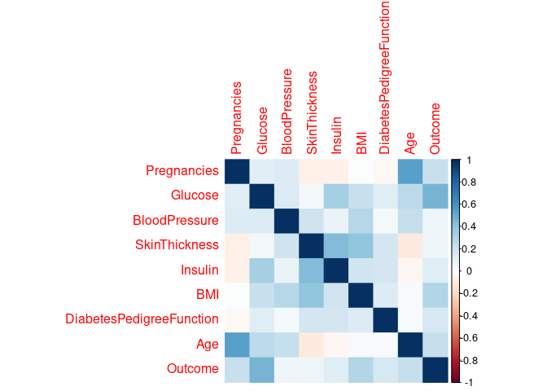

```r
corrplot(correlations, method="color")
```

## Visualization

Visualizations are used to grasp the structure of data and its relations,like how they vary and their relationships with the otehr data.They are said to be EDA.

A matrix of scatterplots is produce for this dataset.

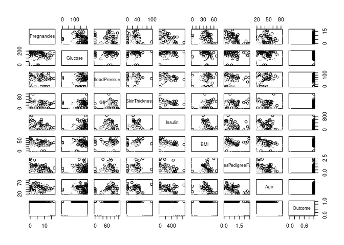

```r
pairs(data, col=data$Outcome)
```

### Glucose and Insulin

```r
data %>% ggvis(~Glucose,~Insulin,fill =~Outcome) %>% layer_points()
```

[output not shown]

### BMI ad DiabetesPedigreeFunction

The BMI and DiabetesPedigreeFunction is plotted here.

```r
data %>% ggvis(~BMI,~DiabetesPedigreeFunction,fill =~Outcome) %>% layer_points()
```

[output not shown]

### Age and Pregnancies

The males have 0 for the pregnancy attribute, which is why we find a lot of values plottinh zero in this grpah.

```r
data %>% ggvis(~Age,~Pregnancies,fill =~Outcome) %>% layer_points()
```

[output not shown]

## Chi Square Test

```r
chisq.test(data)
```

```
##
##  Pearson's Chi-squared test
##
## data:  data
## X-squared = 87061, df = 6136, p-value < 2.2e-16
```

## Preparing the data

```r
set.seed(88)
split <- sample.split(data$Outcome, SplitRatio = 0.75)
data_train <- subset(data, split == TRUE)
data_test <- subset(data, split == FALSE)
```

# Decision Tree Classification

```r
library(rpart)
model4 = rpart(formula = Outcome ~ .,data = data_train)
model4
```

```
## n= 576
##
## node), split, n, deviance, yval
##       * denotes terminal node
##
##  1) root 576 130.8594000 0.34895830
##    2) Glucose< 127.5 353  52.3966000 0.18130310
##      4) Age< 28.5 194  14.6804100 0.08247423 *
##      5) Age>=28.5 159  33.5094300 0.30188680
##       10) Glucose< 106.5 76  10.1052600 0.15789470
##         20) Insulin< 141 68   6.2794120 0.10294120 *
##         21) Insulin>=141 8   1.8750000 0.62500000 *
##       11) Glucose>=106.5 83  20.3855400 0.43373490
##         22) BMI< 27.35 17   0.9411765 0.05882353 *
##         23) BMI>=27.35 66  16.4393900 0.53030300 *
##    3) Glucose>=127.5 223  52.8340800 0.61434980
##      6) Glucose< 154.5 130  32.3769200 0.46923080
##       12) BMI< 30.2 44   7.7272730 0.22727270 *
##       13) BMI>=30.2 86  20.7558100 0.59302330
##         26) Age< 30.5 39   9.4358970 0.41025640
##           52) BloodPressure>=72 20   3.2000000 0.20000000 *
##           53) BloodPressure< 72 19   4.4210530 0.63157890 *
##         27) Age>=30.5 47   8.9361700 0.74468090 *
##      7) Glucose>=154.5 93  13.8924700 0.81720430
##       14) Age>=59.5 7   1.4285710 0.28571430 *
##       15) Age< 59.5 86  10.3255800 0.86046510 *
```

## Prediction

The trained model is used to predict the data for the testing data and for the training data(For checking accuracy purposes and for ROC curve)

```r
predict_train4 = predict(model4, newdata = data_train[1:(length(data_train)-1)])
predict_test4 <- predict(model4, newdata = data_test[1:(length(data_test)-1)])
predict_test4<-round(predict_test4)
confusionMatrix(as.factor(data_test$Outcome), as.factor(predict_test4))
```

```
## Confusion Matrix and Statistics
##
##           Reference
## Prediction   0   1
##          0 103  22
##          1  27  40
##
##                Accuracy : 0.7448
##                  95% CI : (0.677, 0.8048)
##     No Information Rate : 0.6771
##     P-Value [Acc > NIR] : 0.02511
##
##                   Kappa : 0.4284
##
##  Mcnemar's Test P-Value : 0.56771
##
##             Sensitivity : 0.7923
##             Specificity : 0.6452
##          Pos Pred Value : 0.8240
##          Neg Pred Value : 0.5970
##              Prevalence : 0.6771
##          Detection Rate : 0.5365
##    Detection Prevalence : 0.6510
##       Balanced Accuracy : 0.7187
##
##        'Positive' Class : 0
##
```

```r
predict_train4<-as.numeric(predict_train4)
predict_test4<-as.numeric(predict_test4)
```

## ROC Curve

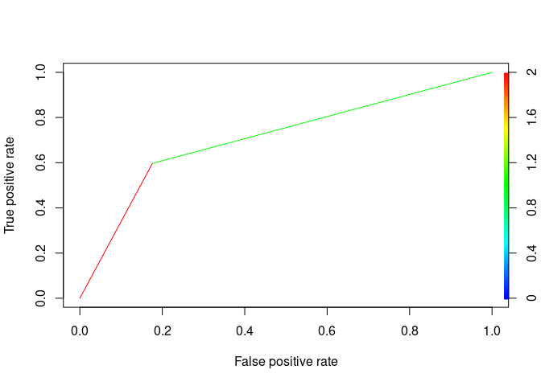

```r
ROCRpred4 <- prediction(predict_test4, data_test$Outcome)
ROCRperf4 <- performance(ROCRpred4, 'tpr','fpr')
plot(ROCRperf4, colorize = TRUE, text.adj = c(-0.2,1.7))
```

## Comparison By comparing the real values with the real data, we can see the how our machine learning algorithm performs.

```r
predict_test_c4 = predict_test4
i = 1
while(i <= length(predict_test4))
{
  if(predict_test4[i] < 0.5)
    predict_test_c4[i] = 0
  else
    predict_test_c4[i] = 1
  i = i + 1;
}
compare <- data.frame(data_test$Outcome,predict_test_c4)
colnames(compare) <- c("Observed Values","Predicted values")
ggplot(data = compare,aes(x = "Observed Values", y = "Predicted values")) + geom_abline() +
  xlab("Observed Values") + ylab("Predicted values") + theme_classic()
```

[output not shown]

```r
head(compare)
```

```
##   Observed Values Predicted values
## 1               0                0
## 2               0                1
## 3               1                1
## 4               1                0
## 5               0                1
## 6               1                1
```

## naive_bayes

```r
library(e1071)
model2 = naiveBayes(x = data_train[1:(length(data_train)-1)],
                        y = data_train$Outcome)
model2
```

```
##
## Naive Bayes Classifier for Discrete Predictors
##
## Call:
## naiveBayes.default(x = data_train[1:(length(data_train) - 1)],
##     y = data_train$Outcome)
##
## A-priori probabilities:
## data_train$Outcome
##         0         1
## 0.6510417 0.3489583
##
## Conditional probabilities:
##                   Pregnancies
## data_train$Outcome     [,1]     [,2]
##                  0 3.373333 2.992742
##                  1 4.711443 3.584176
##
##                   Glucose
## data_train$Outcome    [,1]     [,2]
##                  0 110.368 26.10905
##                  1 143.199 30.90550
##
##                   BloodPressure
## data_train$Outcome     [,1]    [,2]
##                  0 67.73867 19.0847
##                  1 71.03483 20.8728
##
##                   SkinThickness
## data_train$Outcome     [,1]     [,2]
##                  0 19.69600 15.18507
##                  1 22.22886 17.13410
##
##                   Insulin
## data_train$Outcome      [,1]     [,2]
##                  0  70.55733 104.6191
##                  1 106.45771 132.9315
##
##                   BMI
## data_train$Outcome     [,1]     [,2]
##                  0 30.23707 8.062224
##                  1 35.05721 7.274556
##
##                   DiabetesPedigreeFunction
## data_train$Outcome      [,1]      [,2]
##                  0 0.4308613 0.3083066
##                  1 0.5517662 0.3852873
##
##                   Age
## data_train$Outcome     [,1]     [,2]
##                  0 31.55200 11.67505
##                  1 36.58209 10.59549
```

## Prediction

The trained model is used to predict the data for the testing data and for the training data(For checking accuracy purposes and for ROC curve)

```r
predict_train2 = predict(model2, newdata = data_train[1:(length(data_train)-1)])
predict_test2 <- predict(model2, newdata = data_test[1:(length(data_test)-1)])
predict_train2<-as.numeric(predict_train2)
predict_test2<-as.numeric(predict_test2)
head(predict_test2)
```

```
## [1] 1 1 2 1 1 2
```

```r
predict_test2<-predict_test2-c(1)
confusionMatrix(as.factor(data_test$Outcome), as.factor(predict_test2))
```

```
## Confusion Matrix and Statistics
##
##           Reference
## Prediction   0   1
##          0 109  16
##          1  28  39
##
##                Accuracy : 0.7708
##                  95% CI : (0.7048, 0.8283)
##     No Information Rate : 0.7135
##     P-Value [Acc > NIR] : 0.04461
##
##                   Kappa : 0.4738
##
##  Mcnemar's Test P-Value : 0.09725
##
##             Sensitivity : 0.7956
##             Specificity : 0.7091
##          Pos Pred Value : 0.8720
##          Neg Pred Value : 0.5821
##              Prevalence : 0.7135
##          Detection Rate : 0.5677
##    Detection Prevalence : 0.6510
##       Balanced Accuracy : 0.7524
##
##        'Positive' Class : 0
##
```

## ROC Curve

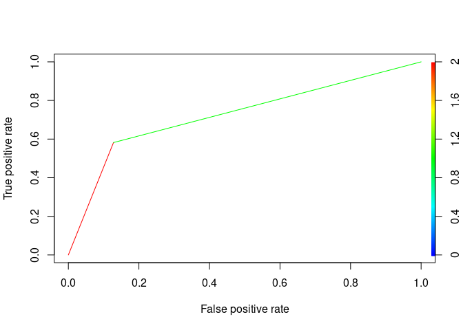

```r
ROCRpred2 <- prediction(predict_test2, data_test$Outcome)
ROCRperf2 <- performance(ROCRpred2, 'tpr','fpr')
plot(ROCRperf2, colorize = TRUE, text.adj = c(-0.2,1.7))
```

## Comparison

By comparing the real values with the real data, we can see the how our machine learning algorithm performs.

```r
predict_test_c2 = predict_test2
i = 1
while(i <= length(predict_test2))
{
  if(predict_test2[i] < 0.5)
    predict_test_c2[i] = 0
  else
    predict_test_c2[i] = 1
  i = i + 1;
}
compare <- data.frame(data_test$Outcome,predict_test_c2)
colnames(compare) <- c("Observed Values","Predicted values")
ggplot(data = compare,aes(x = "Observed Values", y = "Predicted values")) + geom_abline() +
  xlab("Observed Values") + ylab("Predicted values") + theme_classic()
```

[output not shown]

## random_forest

```r
library(randomForest)
model3 = randomForest(x = data_train[1:(length(data_train)-1)],
                        y = data_train$Outcome,
                        ntree = 500)
model3
```

```
##
## Call:
##  randomForest(x = data_train[1:(length(data_train) - 1)], y = data_train$Outcome,      ntree = 500)
##                Type of random forest: regression
##                      Number of trees: 500
## No. of variables tried at each split: 2
##
##           Mean of squared residuals: 0.1597105
##                     % Var explained: 29.7
```

## Prediction

The trained model is used to predict the data for the testing data and for the training data(For checking accuracy purposes and for ROC curve)

```r
predict_train3 = predict(model3, newdata = data_train[1:(length(data_train)-1)])
predict_test3 <- predict(model3, newdata = data_test[1:(length(data_test)-1)])
predict_test3<-round(predict_test3)
confusionMatrix(as.factor(data_test$Outcome), as.factor(predict_test3))
```

```
## Confusion Matrix and Statistics
##
##           Reference
## Prediction   0   1
##          0 111  14
##          1  29  38
##
##                Accuracy : 0.776
##                  95% CI : (0.7104, 0.8329)
##     No Information Rate : 0.7292
##     P-Value [Acc > NIR] : 0.08180
##
##                   Kappa : 0.4801
##
##  Mcnemar's Test P-Value : 0.03276
##
##             Sensitivity : 0.7929
##             Specificity : 0.7308
##          Pos Pred Value : 0.8880
##          Neg Pred Value : 0.5672
##              Prevalence : 0.7292
##          Detection Rate : 0.5781
##    Detection Prevalence : 0.6510
##       Balanced Accuracy : 0.7618
##
##        'Positive' Class : 0
##
```

```r
predict_train3<-as.numeric(predict_train3)
predict_test3<-as.numeric(predict_test3)
```

## ROC Curve

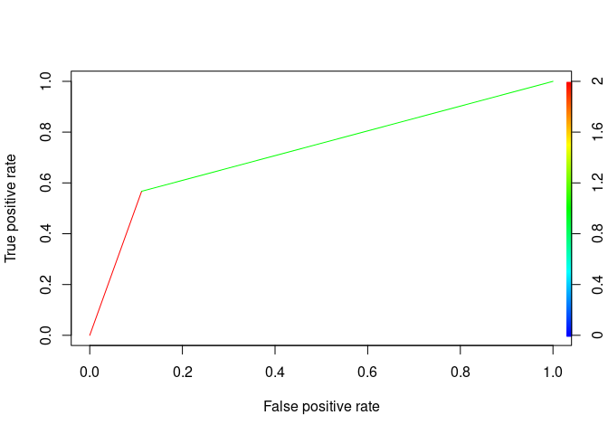

```r
ROCRpred3 <- prediction(predict_test3, data_test$Outcome)
ROCRperf3 <- performance(ROCRpred3, 'tpr','fpr')
plot(ROCRperf3, colorize = TRUE, text.adj = c(-0.2,1.7))
```

## Comparison By comparing the real values with the real data, we can see the how our machine learning algorithm performs.

```r
predict_test_c3 = predict_test3
i = 1
while(i <= length(predict_test3))
{
  if(predict_test3[i] < 0.5)
    predict_test_c3[i] = 0
  else
    predict_test_c3[i] = 1
  i = i + 1;
}
compare <- data.frame(data_test$Outcome,predict_test_c3)
colnames(compare) <- c("Observed Values","Predicted values")
ggplot(data = compare,aes(x = "Observed Values", y = "Predicted values")) + geom_abline() +
  xlab("Observed Values") + ylab("Predicted values") + theme_classic()
```

[output not shown]

```r
head(compare)
```

```
##   Observed Values Predicted values
## 1               0                0
## 2               0                1
## 3               1                1
## 4               1                0
## 5               0                0
## 6               1                1
```

## kernal svm

```r
model5 = svm(formula = Outcome ~ .,
                 data = data_train,
                 type = 'C-classification',
                 kernel = 'radial')
model5
```

```
##
## Call:
## svm(formula = Outcome ~ ., data = data_train, type = "C-classification",
##     kernel = "radial")
##
##
## Parameters:
##    SVM-Type:  C-classification
##  SVM-Kernel:  radial
##        cost:  1
##
## Number of Support Vectors:  333
```

## Prediction

The trained model is used to predict the data for the testing data and for the training data(For checking accuracy purposes and for ROC curve)

```r
predict_train5 = predict(model5, newdata = data_train[1:(length(data_train)-1)])
predict_test5 <- predict(model5, newdata = data_test[1:(length(data_test)-1)])
confusionMatrix(as.factor(data_test$Outcome), as.factor(predict_test5))
```

```
## Confusion Matrix and Statistics
##
##           Reference
## Prediction   0   1
##          0 112  13
##          1  30  37
##
##                Accuracy : 0.776
##                  95% CI : (0.7104, 0.8329)
##     No Information Rate : 0.7396
##     P-Value [Acc > NIR] : 0.14205
##
##                   Kappa : 0.4763
##
##  Mcnemar's Test P-Value : 0.01469
##
##             Sensitivity : 0.7887
##             Specificity : 0.7400
##          Pos Pred Value : 0.8960
##          Neg Pred Value : 0.5522
##              Prevalence : 0.7396
##          Detection Rate : 0.5833
##    Detection Prevalence : 0.6510
##       Balanced Accuracy : 0.7644
##
##        'Positive' Class : 0
##
```

```r
predict_train5<-as.numeric(predict_train5)
predict_test5<-as.numeric(predict_test5)
```

## ROC Curve

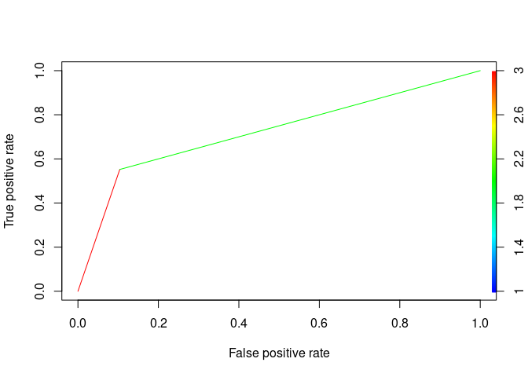

```r
ROCRpred5 <- prediction(predict_test5, data_test$Outcome)
ROCRperf5 <- performance(ROCRpred5, 'tpr','fpr')
plot(ROCRperf5, colorize = TRUE, text.adj = c(-0.2,1.7))
```

## Comparison By comparing the real values with the real data, we can see the how our machine learning algorithm performs.

```r
predict_test_c5 = predict_test5
i = 1
while(i <= length(predict_test5))
{
  if(predict_test5[i] < 0.5)
    predict_test_c5[i] = 0
  else
    predict_test_c5[i] = 1
  i = i + 1;
}
compare <- data.frame(data_test$Outcome,predict_test_c5)
colnames(compare) <- c("Observed Values","Predicted values")
ggplot(data = compare,aes(x = "Observed Values", y = "Predicted values")) + geom_abline() +
  xlab("Observed Values") + ylab("Predicted values") + theme_classic()
```

[output not shown]

```r
head(compare)
```

```
##   Observed Values Predicted values
## 1               0                1
## 2               0                1
## 3               1                1
## 4               1                1
## 5               0                1
## 6               1                1
```

## Logistic regression

```r
model <- glm (Outcome ~ .-Pregnancies + Glucose + BloodPressure + SkinThickness + Insulin + BMI + DiabetesPedigreeFunction + Age, data = data_train, family = binomial)
summary(model)
```

```
##
## Call:
## glm(formula = Outcome ~ . - Pregnancies + Glucose + BloodPressure +
##     SkinThickness + Insulin + BMI + DiabetesPedigreeFunction +
##     Age, family = binomial, data = data_train)
##
## Deviance Residuals:
##     Min       1Q   Median       3Q      Max
## -2.4254  -0.7250  -0.4361   0.7487   2.9829
##
## Coefficients:
##                            Estimate Std. Error z value Pr(>|z|)
## (Intercept)              -8.3339721  0.8159489 -10.214  < 2e-16 ***
## Glucose                   0.0382162  0.0044235   8.639  < 2e-16 ***
## BloodPressure            -0.0088309  0.0060059  -1.470   0.1415
## SkinThickness             0.0007624  0.0081902   0.093   0.9258
## Insulin                  -0.0017095  0.0010823  -1.580   0.1142
## BMI                       0.0792632  0.0169318   4.681 2.85e-06 ***
## DiabetesPedigreeFunction  0.7386714  0.3332368   2.217   0.0266 *
## Age                       0.0204344  0.0095270   2.145   0.0320 *
## ---
## Signif. codes:  0 '***' 0.001 '**' 0.01 '*' 0.05 '.' 0.1 ' ' 1
##
## (Dispersion parameter for binomial family taken to be 1)
##
##     Null deviance: 745.11  on 575  degrees of freedom
## Residual deviance: 552.82  on 568  degrees of freedom
## AIC: 568.82
##
## Number of Fisher Scoring iterations: 5
```

## Prediction

The trained model is used to predict the data for the testing data and for the training data(For checking accuracy purposes and for ROC curve)

```r
predict_train <- predict(model, type = 'response')
predict_test <- predict(model, newdata = data_test, type = 'response')
confusionMatrix(as.factor(data_test$Outcome), as.factor(round(predict_test)))
```

```
## Confusion Matrix and Statistics
##
##           Reference
## Prediction   0   1
##          0 116   9
##          1  30  37
##
##                Accuracy : 0.7969
##                  95% CI : (0.733, 0.8514)
##     No Information Rate : 0.7604
##     P-Value [Acc > NIR] : 0.135087
##
##                   Kappa : 0.5179
##
##  Mcnemar's Test P-Value : 0.001362
##
##             Sensitivity : 0.7945
##             Specificity : 0.8043
##          Pos Pred Value : 0.9280
##          Neg Pred Value : 0.5522
##              Prevalence : 0.7604
##          Detection Rate : 0.6042
##    Detection Prevalence : 0.6510
##       Balanced Accuracy : 0.7994
##
##        'Positive' Class : 0
##
```

## ROC Curve

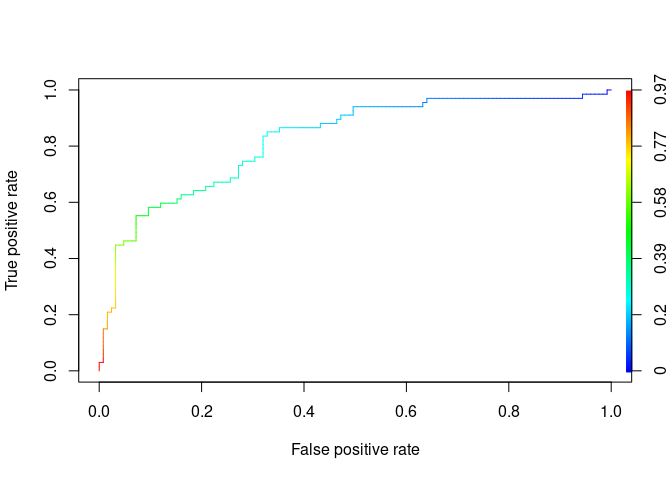

```r
ROCRpred <- prediction(predict_test, data_test$Outcome)
ROCRperf <- performance(ROCRpred, 'tpr','fpr')
plot(ROCRperf, colorize = TRUE, text.adj = c(-0.2,1.7))
```

## Comparison

By comparing the real values with the real data, we can see the how our machine learning algorithm performs.

```r
predict_test_c = predict_test
i = 1
while(i <= length(predict_test))
{
  if(predict_test[i] < 0.5)
    predict_test_c[i] = 0
  else
    predict_test_c[i] = 1
  i = i + 1;
}
compare <- data.frame(data_test$Outcome,predict_test_c)
colnames(compare) <- c("Observed Values","Predicted values")
ggplot(data = compare,aes(x = "Observed Values", y = "Predicted values")) + geom_abline() +
  xlab("Observed Values") + ylab("Predicted values") + theme_classic()
```

[output not shown]

```r
head(compare)
```

```
##    Observed Values Predicted values
## 6                0                0
## 8                0                0
## 9                1                1
## 10               1                0
## 11               0                0
## 14               1                1
```